Your Trip

The Lads Travel Co.

# Rome. Pompeii. Tivoli. *The Amalfi Coast.*

Two options for one of the great cities. Five days that reveal themselves slowly, a day trip that redefines what ruins can be, and an aperitivo tradition that changes how you budget the entire trip. Both Lads have been. 43 spots in the database, 33 personally rated.

33

Rated Spots

5

Days in Rome

2

Trip Options

Quick Read

## Two Ways to *Do Italy Right*

The difference between Option A and Option B is not quality. It is time. Option A gives a group seven to nine days to know Rome properly—not three days of rushing between sites but five full days with the city actually revealing itself, plus Pompeii, Tivoli, and a day trip to the Amalfi Coast. Option B takes the same Rome leg and adds three to four nights on the Amalfi Coast, with the smartest logistical move in the itinerary: visiting Pompeii on the transit day south.

### Option A

Rome · 7–9 Days Personally Validated

- Five full days in Rome with Yellow Square as the social anchor
- Pompeii full-day trip from Rome via Frecciarossa
- Tivoli full day—Villa d'Este + Villa Adriana
- Amalfi Coast day trip through Naples
- 43 spots in the database, 33 personally rated, across bars, food, and attractions

### Option B

Rome + Amalfi Coast · 10–14 Days Rome Validated · Amalfi Researched

- Everything in Option A, plus 3–4 nights on the Amalfi Coast
- Pompeii on the transit day—luggage stored, ruins visited, private transfer to coast
- Amalfi Town as base: flat, central, ferry hub
- Path of the Gods hike, private boat charter, Music on the Rocks
- Day trip to Positano—do not pay to stay there

Both Lads Know This

Ask how many days and whether they want to swim in the sea. Seven to nine days and Rome deserves every one of them—Option A. Ten to fourteen days and the Amalfi Coast is a reason to go to Italy at all—Option B. The Pompeii transit day strategy makes Option B more efficient than it looks on paper.

The City

## Rome—*Five Days Is Not Too Long*

People think Rome is a three-day city. They are wrong. Rome is a city that layers. The first day you find the Colosseum and feel like a tourist. By the fifth day you know which bar has the best aperitivo buffet, you have wandered into two churches that were not in the guidebook, and you have eaten carbonara at 2pm on a Tuesday because it felt right. Give Rome the time.

[figure not shown]

Sant'Ignazio di Loyola—the painted dome is not real. One of Rome's most underrated moments.

[figure not shown]

La Sella Roma—artisan leather goods. Part of the original Lads Rome day flow.

### Yellow Square—The Social Anchor

Both Lads Know This

This is the right place to stay for this group. Castro Pretorio neighbourhood, ten minutes from Termini on foot. Private en suite dorms in 4, 6, and 8-bed configurations. The YellowBar across the street does free pasta hour from 7pm to 8pm—it functions as a meetup point for the hostel population every evening and is where the night starts.

#### Yellow Square Hostel

Castro Pretorio. 10 min walk from Termini. Tactically excellent for Frecciarossa to Naples and regional trains to Tivoli.

€35–50/night

Research-Based

Yellow Square is holding strong post-Jubilee. The neighbourhood is safe, residential, and surrounded by affordable trattorias. RomeHello is rated higher for cleanliness but lacks the social energy and nightlife integration that makes Yellow Square the better fit for this type of group.

### The Major Sites

Both Lads Know This

Do the Colosseum twice if possible—once during the day and once at night. The experience is completely different after dark. Check the Giardinetto del Monte Oppio viewpoint for the best elevated view. The Vatican is its own country and requires half a day at minimum—do not try to do it quickly.

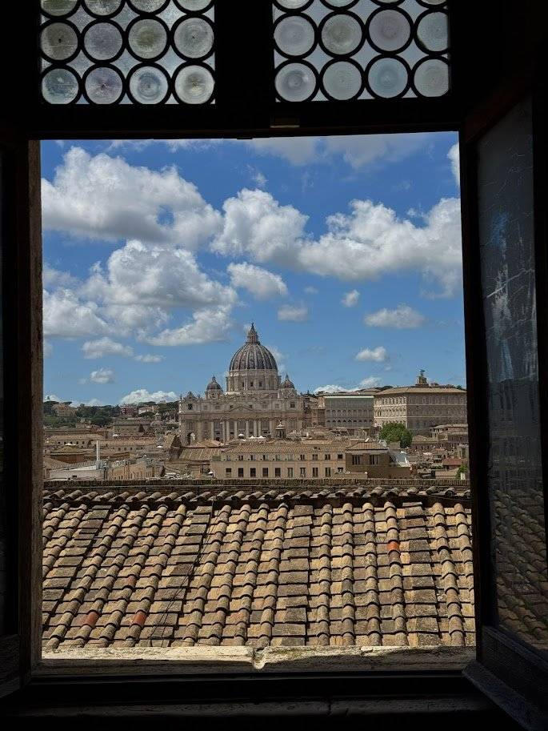

St. Peter's through the window—terracotta rooftops and the dome that defines the skyline.

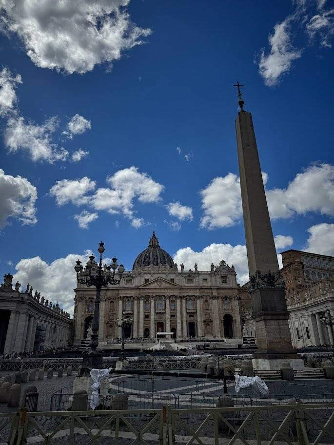

St. Peter's Square. Free entry. No shorts—strict dress code enforced.

#### Colosseum

Buy timed entry online in advance. See it during the day and at night. Do not pay a scalper.

4.8★

$$

#### Roman Forum + Palatine Hill

Ticket includes Colosseum. Larger than expected—give it time.

4.8★

$$

#### Vatican Museums + Sistine Chapel

Book online, arrive early. Half day minimum. Worth every cent.

4.6★

€20+

#### St. Peter's Basilica

Free entry. Largest church in the world. Climb the dome for panoramic views. No shorts.

4.8★

Free

#### Pantheon

Go if you have time. The oculus alone is worth the stop.

4.8★

€5

#### Trevi Fountain

Go before 8am. Toss a coin. After that it belongs to the crowds.

4.7★

Free

#### Castel Sant'Angelo

Rooftop has excellent river and city views.

4.7★

$$

#### Chiesa di Sant'Ignazio di Loyola

Trompe-l'oeil ceiling—the painted dome is not real. Underrated and free.

4.8★

Free

#### Monument to Victor Emmanuel II

Pay for the lift to the top for panoramic views. Free at ground level.

4.8★

Free/€

### Five Days in Rome—The Arc

**Day 1**—Arrive, check into Yellow Square, Trastevere at night. Let the city introduce itself.

**Day 2**—Vatican full day. Bonci Pizzarium for pizza al taglio. Prati neighbourhood for aperitivo.

**Day 3**—Colosseum and Roman Forum. Campo de' Fiori in the evening.

**Day 4**—Pompeii full day from Rome (Option A), or rest day before Tivoli.

**Day 5**—Tivoli full day. Return to Rome for a final Trastevere dinner.

That is the structure. The specific stops fill themselves in.

Eat & Drink

## The Food Is *the Reason You Came*

[figure not shown]

Both Lads Know This

Tonnarello in Trastevere for cacio e pepe. Bonci Pizzarium near the Vatican for pizza al taglio. Mancini in Testaccio for carbonara. Supplì Roma for supplì—try them everywhere in the city, compare at Supplì Roma. Giollitti Gelato near the Pantheon. Antico Forno Roscioli for pizza bianca in the morning. Get there early.

#### Tonnarello

Trastevere. Cacio e pepe destination. Both Lads validated.

★

$$

#### Bonci Pizzarium

Near the Vatican. Pizza al taglio—sold by weight. The best in Rome.

★

$

#### Mancini

Testaccio. Carbonara institution.

$

#### Supplì Roma

Rome's best supplì. Try them everywhere in the city, compare here.

4.7★

€1–10

#### Giollitti Gelato

Near the Pantheon. Classic Roman gelato.

$

#### Antico Forno Roscioli

Pizza bianca in the morning. Get there early.

$

#### Two Sizes

15K+ reviews. One of the highest-rated sweet spots in Rome.

4.7★

$

#### Forno Campo de' Fiori

Bakery on the square. Pizza al taglio.

4.5★

€1–10

### The Aperitivo Strategy—How Rome Does the Evening

This is the most effective budgeting strategy in Rome, and one of the best social experiences in the city. Buy one drink for €10–15 at an aperitivo bar between 6:30pm and 9pm. The bar provides a buffet—pasta salads, bread, pizza bianca, cured meats. For a group of eight this comfortably replaces a sit-down dinner. Build it into the evening routine.

For a group spending five nights in Rome, the aperitivo strategy saves €50–75 per person on food across the trip. This is not a compromise—the food is good, the settings are often remarkable, and aperitivo hour is one of the defining social rituals of the city.

#### Freni e Frizioni

Trastevere. Former mechanic shop. Most generous buffet. Outdoor terrace. High energy.

4.2★

€10–20

#### Salotto 42

Piazza di Pietra. You drink aperitivo in front of a Roman temple. The best setting in Rome.

€10–20

#### Il Piccolo Diavolo

Prati. Pizza bianca and pasta salads. Good stop near the Vatican.

€10–20

#### Blackmarket Hall

Monti. Speakeasy atmosphere, more refined plates. The Monti neighbourhood is worth the trip on its own.

4.5★

€20–30

### Bars & Drinks

Both Lads Know This

Salotto 42 on the Piazza di Pietra for aperitivo—you drink in front of a Roman temple. The Basement is one of the stronger cocktail spots in Rome at 4.8 stars. Ma Che Siete Venuti A Fà in Trastevere is a tiny craft beer standing-room bar—exactly the kind of place this group will gravitate toward.

#### Ma Che Siete Venuti A Fà

Trastevere. Tiny craft beer bar. Standing room only. The kind of place worth finding.

4.6★

€1–10

#### Bar San Calisto

Trastevere institution. Locals, students, €1 beers.

4.5★

€1–10

#### Open Baladin

Italian craft beer pub. Excellent tap selection.

4.4★

€10–20

#### Drink Kong

Anime-inspired. One of Rome's most acclaimed cocktail bars.

4.3★

$$$

#### Jerry Thomas Speakeasy

Prohibition-style. Rome's original speakeasy. Reserve ahead.

4.5★

$$$

The Historical Moment

## The Jubilee Year 2025 and the Passing of Pope Francis

What follows is not a religious recommendation. It is an accurate account of what both Lads witnessed during their five days in Rome—a coincidence of timing that placed them in the city during two events that will be written about for generations.

The year 2025 was declared a Jubilee Year by the Catholic Church—a sacred year of pilgrimage, indulgence, and renewal that occurs every 25 years. For this Jubilee, the Holy Doors at all four major basilicas in Rome were opened. Pilgrims from around the world came to Rome to walk through these doors—an act of faith that carries specific theological weight within Catholic tradition.

Both Lads Know This

Both Lads walked through the Holy Doors and witnessed the Jubilee atmosphere throughout the city. The pilgrimage energy was unlike anything either had experienced in a major city. Rome felt different—purposeful, reverential, and alive in a way that went beyond ordinary tourism.

[figure not shown]

St. Peter's Basilica. The dome, the light, the baldachin. Both Lads were here.

Pope Francis passed away during the Jubilee Year. Both Lads were in Rome at the time. They went to Saint Peter's Basilica to see his body lying in state and witnessed the funeral procession through the city. This was not planned. It was one of those moments travel sometimes delivers that no amount of planning can anticipate—the sense of being present at something genuinely historic.

Pope Francis led the Catholic Church for over a decade and was one of the most globally significant figures of the 21st century. The scenes in Rome—the crowds, the silence, the procession through the ancient streets—were unlike anything either Lad had witnessed before or since.

Research-Based

The Holy Doors officially closed January 6, 2026 under Pope Leo XIV. They are now sealed and will remain so until the next Ordinary Jubilee in 2050. Rome is now in the post-Jubilee era. The city has retained the infrastructure improvements made for 2025, but the specific Jubilee atmosphere no longer exists. Groups visiting in 2026 will see a Rome that is returning to its secular tourism baseline—extraordinary in its own right, but different from what both Lads experienced.

This context shapes how the Lads present Rome. It is the greatest city in the world on an ordinary day. Both Lads happened to be there on something other than an ordinary day.

Day Trip

## Pompeii—*The Strongest Recommendation in the Series*

Personally Validated · Highest Recommendation

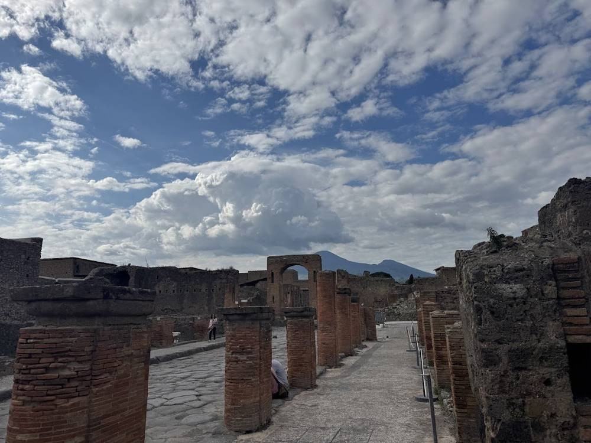

Pompeii. Two thousand years ago this street was full. Vesuvius sits behind it the same way it did then.

Both Lads Know This

Nothing I have seen in travel compares to the Garden of the Fugitives. You walk into a room and there are the plaster casts of people frozen at the moment the eruption killed them—mid-motion, mid-breath, 2,000 years ago. Pompeii is not a ruin. It is a city that was stopped in time.

### Getting There

Frecciarossa from Roma Termini to Napoli Centrale—70 minutes. Transfer to the Circumvesuviana toward Sorrento. Alight at Pompei Scavi—Villa dei Misteri station. You are at the entrance. Total travel time from Roma Termini: approximately 2.5 hours. Depart by 7am for a full day.

Research-Based · 2026

Daily visitor cap of 20,000. Timed entry is now required. Tickets are named. Book online before you go. Pompeii Express (€18–20) covers the main site. Pompeii Plus (€24–25) adds the Villa of Mysteries—worth the upgrade.

### The Garden of the Fugitives

The standard Pompeii highlights—the Forum, the Amphitheatre, the Lupanare—are all unmissable. But the Garden of the Fugitives is the reason Pompeii is unlike any other archaeological site on earth. The plaster casts of the victims, frozen in the positions they died in nearly two millennia ago, are the emotional anchor of the entire day. Do not miss it. Do not rush past it.

Skip Vesuvius unless the group specifically wants it. The view from the amphitheatre is sufficient. Pompeii in summer exceeds 35°C with minimal shade. Bring water. More than you think.

### The Transit Day Strategy (Option B)

Research-Based

This is the logistical insight that makes Option B work. On the transit day from Rome to the Amalfi Coast, store luggage at the left luggage at Pompeii Scavi station. Spend the afternoon in the ruins. Take a private transfer from the Pompeii gates directly to the Amalfi villa. No wasted day. No doubling back. Pompeii is fully integrated into the journey south.

Do not combine Pompeii and Naples in a single day. This is the most common mistake on the southern Italy leg. Naples needs its own day or skip it. Pompeii needs its own day or the transit strategy.

In Option B, Pompeii is visited on the transit day south to the Amalfi Coast—luggage stored at the station, ruins explored, private transfer directly to the villa. Toggle to Option B above to see the full transit strategy.

[Book: Pompeii + Amalfi Coast + Sorrento Day Trip →](https://gyg.me/c6cN0bz2)

Day Trip

## Tivoli—*Essential, Not Optional*

Both Lads Know This

Essential day trip from Rome. Villa d'Este alone is worth the journey. Both sites together make a full day that is unlike anything available in the city itself. The medieval old town of Tivoli for lunch between the two villas. BAR FORESI dal 1930 is in the database—4.9 stars, worth a stop near Villa d'Este.

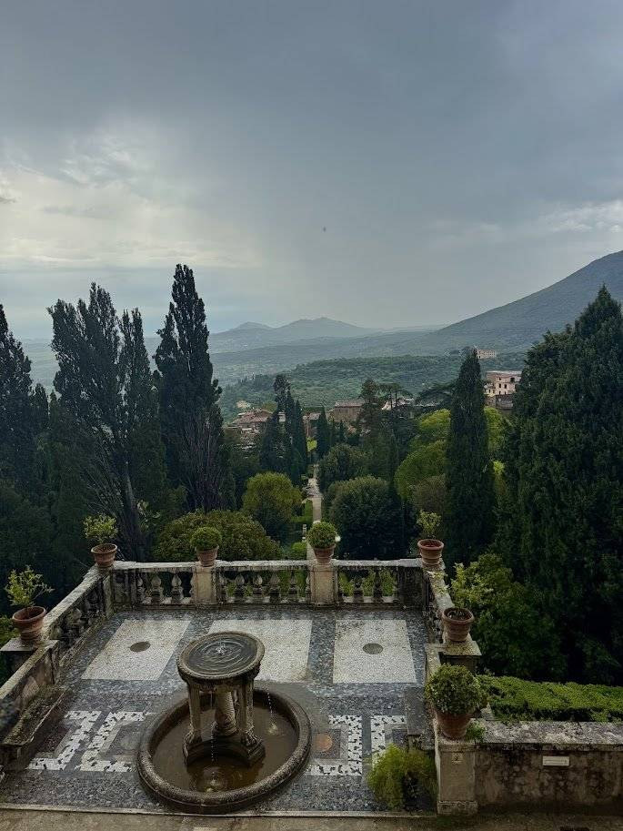

Villa d'Este—500+ fountains, gravity-fed water organs, and this view of the valley below.

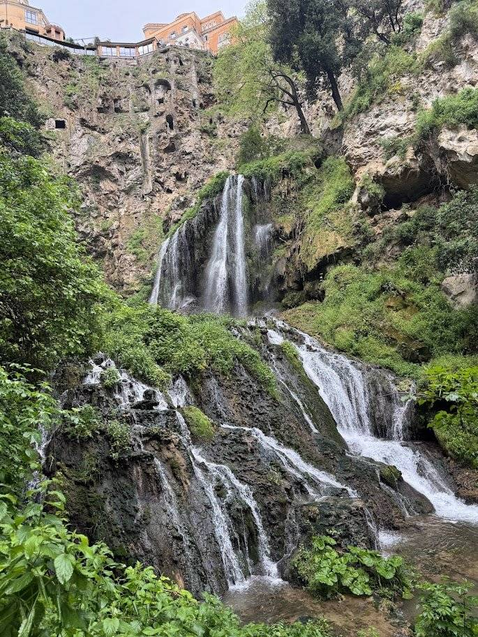

The waterfalls near Tivoli. Ancient engineering meets natural force.

### The Full Day

**Villa d'Este**—A Renaissance masterpiece. 500+ fountains and gravity-fed water organs. The engineering of the Organ Fountain and the scale of the One Hundred Fountains are the highlights. Two-hour visit. Both Lads completed this personally.

**Tivoli old town lunch**—BAR FORESI dal 1930 is in the database at 4.9 stars.

**Villa Adriana (Hadrian's Villa)**—Emperor Hadrian's retreat. A sprawling archaeological complex once larger than the centre of Imperial Rome itself. A site for exploration, not viewing. More walking, less shade than Villa d'Este. Superior sense of scale and ancient atmosphere.

Return to Rome by 6–7pm for Trastevere aperitivo.

Research-Based

For a group of 4–8, hire a private van from Rome. Approximately €400–550 for the full day. The two villas are 5km apart and not easily connected by local public transport. A private van solves this and gives the group flexibility. 9am departure from Rome.

The Coast

## The Amalfi Coast—*Beautiful Enough to Come Back For*

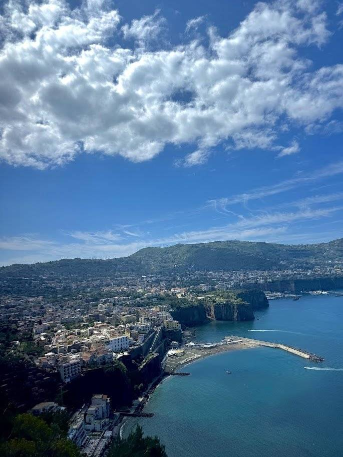

The Amalfi Coast from above. The blues are not exaggerated. They are actually like this.

Both Lads Know This

Both Lads did the Amalfi Coast as a day trip through Naples. It is genuinely beautiful. The coastal drive, the water, the towns—it earns everything said about it in a single day. Beautiful enough to come back for the overnight stay in Option B.

In Option A, the coast is a single day trip from Rome. Train to Naples, ferry or private transfer along the coast. A single day gives you the drive, the water, and a sense of what the coast is. It does not give you the boat charter or the Path of the Gods. The Black Sheep Craft Pub in Sorrento is in the database at 4.5 stars—good stop on the day trip route.

### Amalfi Town as the Base (Option B)

Research-Based

Amalfi Town is the recommendation. Flat, central piazza, ferry hub. The ability to move a group of eight on flat ground between the ferry, bus, and waterfront is a massive logistical advantage over Positano. Positano is spectacular but built vertically—moving the group from a hilltop villa to the beach takes 30 minutes of stair climbing each way. Amalfi Town removes that friction entirely. Food and drink costs run 25% less than Positano immediately.

#### Positano

Day trip by ferry for Music on the Rocks—the definitive coast nightclub. Do not pay to stay there.

Day trip

#### Praiano — Africana Famous Club

Nightclub built into a sea cave. Worth knowing as an alternative night out.

$$

### Path of the Gods

Research-Based

6.5km from Bomerano to Nocelle. 3–4 hours. Views of Capri and the Li Galli islands. The definitive group outdoor activity on the coast. Start at Bomerano (bus from Amalfi, uphill) and walk the lower path toward Nocelle—mostly flat or downhill. Finish in Positano for a beer at the beach. Do not start from Positano—1,700 steps up is the wrong direction.

### Private Boat Charter

Research-Based

$1,200–1,800 for up to 12 people, full day with skipper. For a group of 8, that is approximately $150–225 per person—comparable to two days of beach club entry but gives access to the Furore Fjord, the Emerald Grotto, and private swimming coves inaccessible by land. Far superior to lido culture for this group.

### Getting Around the Coast

**Ferry**—the right choice. €10–15 between major towns. 25 minutes Positano to Amalfi. Book in advance in summer.

**SITA bus**—cheap (€1.50–3) but overcrowded in summer, unreliable for groups. Manageable in September.

**Private transfer**—most efficient with luggage. €180–250 Naples to Amalfi for a group van.

**Do not rent a car**—parking is virtually impossible and costs €50–80 per day where it exists.

When to Go

## September Is *the Optimal Window*

Post-Labor Day is the optimal window for both options. The Tyrrhenian Sea holds enough thermal mass for swimming through late September. Air temperature drops to a manageable 22–26°C. Accommodation pricing falls 15–20% from August peak. The crowds thin but the city and coast remain fully operational.

#### September

Recommended

Sea warm enough for swimming. Crowds thinning. Prices drop 15–20% from peak. Ferries and restaurants fully operational. The sweet spot.

#### April–May

Second Best

Rome post-Easter. Greenery peak. Tivoli fountains in full condition. Cooler than summer. Amalfi extension viable but swimming is cooler.

#### June–August

High Friction

Rome exceeds 35°C. Pompeii in full sun requires serious hydration. SITA buses inaccessible in peak months. Highest pricing of any window.

#### Winter

Rome Only

Rome works in winter—more intimate, less crowded. But the Amalfi Coast largely decommissions October through March. Option B is not viable.

Getting There & What It Costs

## Flights, Budget, and *Ways to Save*

### Flights

Chicago O'Hare (ORD) is the primary recommendation. Direct service from United, American, and ITA Airways means more competition and lower fares. Detroit (DTW) is primarily Delta and Air France via CDG—adds approximately $150–200 over ORD in every window.

Research-Based

ITA Airways integrated into Star Alliance as of 2026. The ORD–FCO route (AZ629) is now a prime choice for United MileagePlus and Miles and More members. Shoulder season fares have been sighted at $736 RT. Book 4–6 months out for the September window.

| Window | ORD | DTW |
| --- | --- | --- |
| Summer (Jun–Aug) | $1,100–1,400 | $1,250–1,600 |
| Shoulder (Apr–May, Sep–Oct) | $750–950 | $900–1,150 |
| Winter (Nov–Mar) | $600–800 | $750–1,000 |

### Cost Model—Per Person Estimates

Lean scenario: Yellow Square dorms, aperitivo-as-dinner most nights, public transport for Tivoli, pack lunches for Pompeii. Generous scenario: Tivoli private van, private boat charter, premium Amalfi villa, dining out every night.

| Category | Option A (Lean) | Option A (Generous) | Option B (Generous) |
| --- | --- | --- | --- |
| Flights (ORD) | $750 | $950 | $950 |
| Accommodation | €245–350 | €350–500 | €600–900 |
| Food & Drink | €200–300 | €400–600 | €550–800 |
| Transport (local) | €80–120 | €200–300 | €350–500 |
| Activities | €60–100 | €100–180 | €250–400 |

### Ways to Save

#### Aperitivo as Dinner

€10–15 drink includes a buffet spread, 6:30–9pm. Built into the evening routine, this saves €50–75 per person over five nights.

#### Skip the Roma Pass

The 72-hour pass costs €58. The two free sites rarely break even for this itinerary. Buy individual tickets instead.

#### Always Pay in Euros

Never select USD at card terminals. Dynamic Currency Conversion adds 3–5% on every transaction.

#### Coperto Is Not a Tip

Cover charge of €1–3 per person at restaurants is standard. Additional tipping is not expected. Round up at a group dinner. Do not tip 20%.

#### Amalfi Town Over Positano

25% cheaper for food and drink immediately. Self-cater breakfasts from actual supermarkets. Free beach sections at every major beach—arrive by 9:30am.

#### Boat Charter Split 8 Ways

Better value than 8 individual lido entries across multiple days. $150–225 per person for a full day on the water.

Before You Go

## What First-Timers *Get Wrong*

01

Combining Pompeii and Naples in One Day

The most common mistake on the southern Italy circuit. Pompeii alone needs 4–6 hours and 2.5 hours of travel each way from Rome. Naples is a full day in its own right. Do not try to do both.

02

Staying in Positano

Positano is visually extraordinary and logistically punishing for a group. Thirty minutes of stairs between the villa and the beach in either direction. Dining costs 25% more than Amalfi Town. Day trip to Positano for Music on the Rocks. Do not pay to stay there.

03

Skipping the Aperitivo

The most effective financial move in Rome is consistently the one groups skip because they do not know about it. €10–15 drink gets a substantial buffet from 6:30pm to 9pm. This functions as dinner. Use it every evening.

04

Buying the Roma Pass

The 72-hour pass costs €58. The two free sites would typically be the Colosseum and Capitoline Museums—roughly €35 in ticket value. Skip the pass. Use contactless on the metro and buy the Colosseum ticket directly online.

05

Over-Tipping

The coperto of €1–3 per person is standard and unavoidable—it is not a tip. Additional tipping is not expected. Round up the bill at a group dinner. Do not tip 20%.

06

Taking the SITA Bus in August

Cheap and runs on time—when the driver stops. Buses are frequently so full they bypass stops entirely, leaving groups stranded for hours on a narrow coastal road. In September this is manageable. In August take the ferry.

07

Skipping Tivoli

Groups condense the Rome leg and drop Tivoli because it seems like a detour. It is not a detour. Villa d'Este and Villa Adriana together are a full day of genuinely world-class heritage. Both Lads did this day and it belongs in the itinerary.

08

Skipping the Garden of the Fugitives

The Forum, the Amphitheatre, the Lupanare are all unmissable. But the Garden of the Fugitives is the reason Pompeii is unlike any other archaeological site on earth. Do not miss it. Do not rush past it.

Your Maps

## Google Maps Lists

Every spot in this framework, pinned and organized. Open on your phone when you land.

[Rome Food & Drink →](https://maps.app.goo.gl/kmFjNeA6k8BHuHWT8) [Rome Attractions →](https://maps.app.goo.gl/RAS5mqRhc6BYTa5D6)

MORE FRAMEWORKS

Spain Prague + Vienna Dublin + Galway